# Resumen de análisis de tipologías

Francisca Vasquez Estay

2025-09-08

## Descripción general

Este proyecto analiza las estructuras de redes de parentesco (kinship networks) derivadas de la encuesta CASEN 2020 de Chile. El objetivo principal es identificar tipologías estructurales en las redes familiares y examinar su relación con variables sociodemográficas como ingresos, ubicación geográfica, composición étnica y género.

## Flujo de análisis

### 1. Preparación de los Datos (1.Integracion_nuevas_variables_fv.R)

- Carga y limpieza de datos originales de CASEN 2020
- Creación de variables derivadas (edad laboral, legal, etc.)
- Filtrado de viviendas con IDs duplicados
- Cálculo de estadísticos descriptivos por hogar (household):
  - Porcentaje de hombres/mujeres
  - Porcentaje de población indígena
  - Porcentaje de empleo
  - Porcentaje con enfermedades crónicas
  - Ingreso promedio del hogar
  - Edad promedio y desviación estándar

```r
# measurements
load("Análisis de viviendas/Descriptives/medidas_redes.RData")
head(measurements)
```

[output not shown]

### 2. Procesamiento de Redes (2.Redes_sin_atributos.R)

- Eliminación de atributos de nodos en cuatro tipos de redes:
  - Redes de descendencia (descent)
  - Redes de matrimonio (marriage)
  - Redes de dependencia (dependency)
  - Redes de parentesco completo (kinship)
- Preparación de redes para análisis estructural puro

### 3. Identificación de tipologías (3.Redes_sin_atributos_visualizacion.R)

- Cálculo de “huellas digitales” estructurales (fingerprints) para cada red
- Agrupamiento de redes por similitud estructural
- Identificación de las 48 tipologías más frecuentes (que cubren ~80% de los casos)

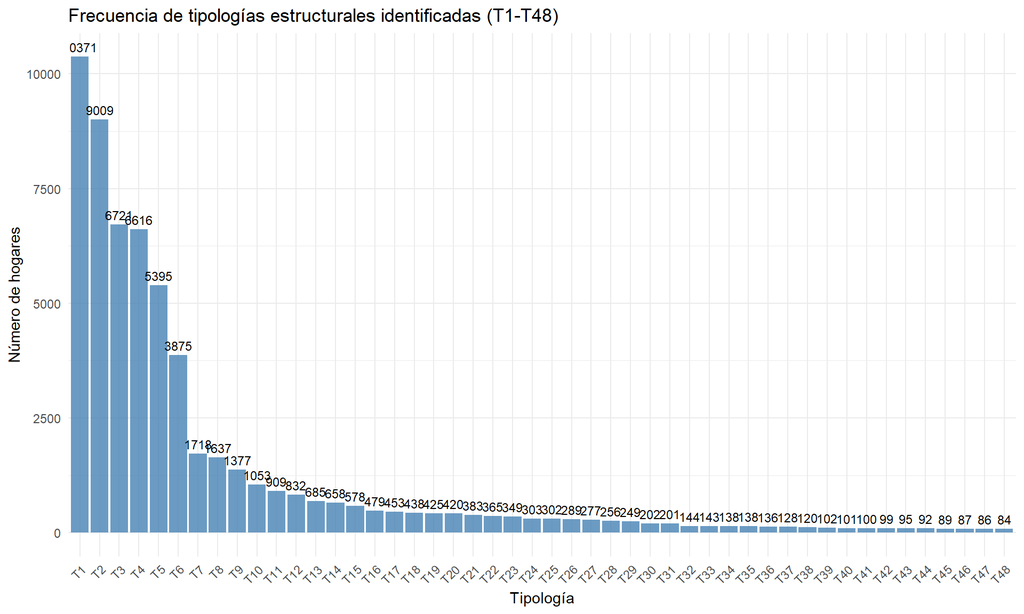

```r
# Cargar datos de frecuencia de tipologías
tipologia_df <- read.csv("Análisis de viviendas/Analisis/Resultados_Tipologias/Reportes/resumen_tipologias.csv")

# Filtrar solo T1 a T48
tipologia_df <- tipologia_df %>%
  filter(Tipologia %in% paste0("T", 1:48)) %>%
  mutate(Tipologia = factor(Tipologia, levels = paste0("T", 1:48)))

# Gráfico de frecuencia de tipologías
ggplot(tipologia_df, aes(x = Tipologia, y = Frecuencia)) +
  geom_col(fill = "steelblue", alpha = 0.8) +
  geom_text(aes(label = Frecuencia), vjust = -0.5, size = 3) +
  labs(title = "Frecuencia de tipologías estructurales identificadas (T1-T48)",
       x = "Tipología", y = "Número de hogares") +
  theme_minimal() +
  theme(axis.text.x = element_text(angle = 45, hjust = 1))
```

- Visualización de ejemplos representativos de cada tipología

```r
# Cargar ejemplos de redes (ejecutar previamente)
load("Análisis de viviendas/Redes/kinship_igraph_no_attrs.RData")
load("Análisis de viviendas/Data/fingerprints.RData")

# Obtener ejemplos de las 6 tipologías más frecuentes
freq_table <- table(fingerprints)
unique_fps <- names(sort(freq_table, decreasing = TRUE))
examples <- lapply(unique_fps[1:6], function(fp) {
  idx <- which(fingerprints == fp)[1]
  kinship_igraph_no_attrs[[idx]]$kinship_net
})

# Configurar layout para múltiples gráficos
par(mfrow = c(2, 3), mar = c(1, 1, 2, 1))

for (i in 1:6) {
  plot(examples[[i]],
       main = paste("Tipología T", i, "\nFrecuencia:", freq_table[unique_fps[i]]),
       vertex.size = 15,
       vertex.color = "lightblue",
       vertex.frame.color = "white",
       vertex.label.color = "black",
       edge.arrow.size = 0.5,
       layout = layout_with_fr)
}
```

[output not shown]

- Análisis de puntos de quiebre para determinar tipologías significativas

### 4. Descripción de tipologías (4.Descripción_tipologías.R)

Caracterización sociodemográfica de cada tipología: - Edad y género del jefe de hogar - Distribución urbano/rural y por macrozonas - Composición étnica (porcentaje indígena y extranjero) - Distribución de ingresos por quintiles

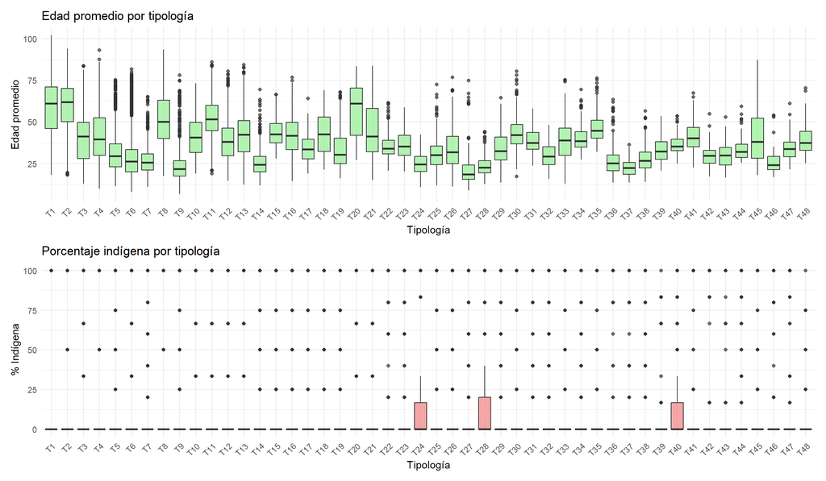

```r
load("Análisis de viviendas/Data/Data_con_tipología.RData")

# Filtrar solo T1 a T48 y ordenar
data_con_tipologia <- data_con_tipologia %>%
  filter(tipologia %in% paste0("T", 1:48)) %>%
  mutate(tipologia = factor(tipologia, levels = paste0("T", 1:48)))

# Gráfico de edad promedio por tipología
p1 <- ggplot(data_con_tipologia, aes(x = tipologia, y = edad.prom)) +
  geom_boxplot(fill = "lightgreen", alpha = 0.7) +
  labs(title = "Edad promedio por tipología", x = "Tipología", y = "Edad promedio") +
  theme_minimal() +
  theme(axis.text.x = element_text(angle = 45, hjust = 1))

# Gráfico de porcentaje indígena por tipología
p2 <- ggplot(data_con_tipologia, aes(x = tipologia, y = porc_ind)) +
  geom_boxplot(fill = "lightcoral", alpha = 0.7) +
  labs(title = "Porcentaje indígena por tipología", x = "Tipología", y = "% Indígena") +
  theme_minimal() +
  theme(axis.text.x = element_text(angle = 45, hjust = 1))

# Combinar gráficos
p1 / p2
```

### 5. Análisis Estadístico de Tipologías (5.Análisis_de_tipologias_frecuentes.R)

- Pruebas de chi-cuadrado para evaluar asociaciones entre tipologías y variables categóricas.
- Gráficos mosaico para visualizar asociaciones.
- Heatmaps de significancia estadística.

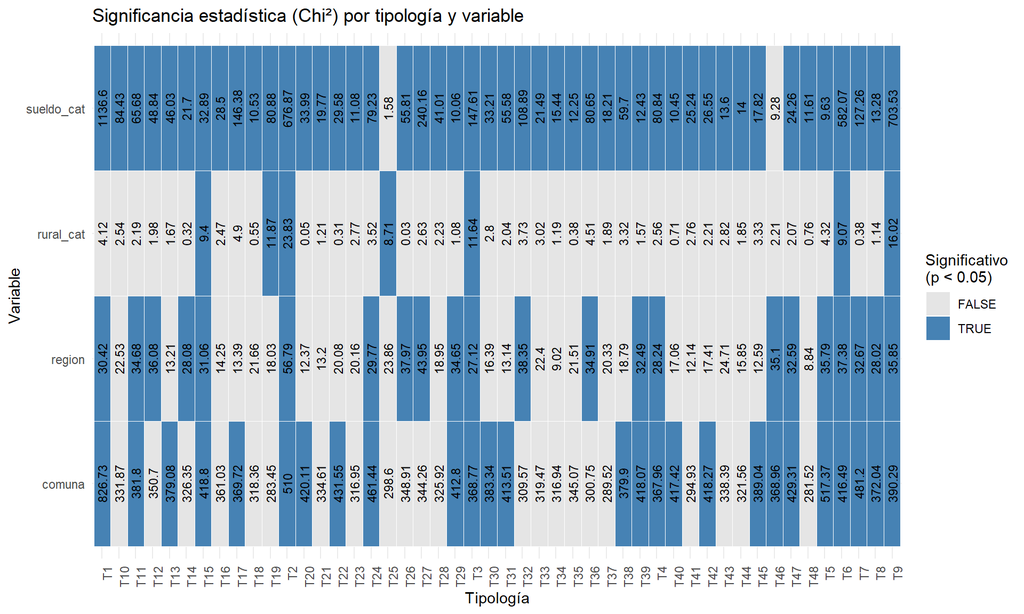

  ```r
  # Heatmap de significancia estadística
  resultados_chi <- read.csv("Análisis de viviendas/Analisis/resultados_chi_tipologias.csv")

  ggplot(resultados_chi, aes(x = Tipologia, y = Variable, fill = p_value < 0.05)) +
    geom_tile(color = "white") +
    geom_text(aes(label = round(Chi2, 2)), size = 3,angle = 90, color = "black") +
    scale_fill_manual(values = c("TRUE" = "steelblue", "FALSE" = "gray90"),
                  name = "Significativo\n(p < 0.05)") +
    labs(title = "Significancia estadística (Chi²) por tipología y variable",
     x = "Tipología", y = "Variable") +
    theme_minimal() +
    theme(axis.text.x = element_text(angle = 90, hjust = 1))
  ```

### 6. Visualización de roles Familiares (6.Visualización_jefe_de_hogar.R)

- Análisis de la posición del jefe de hogar en cada tipología estructural
- Distribución de género por posición estructural
- Edad promedio por nodo en la estructura familiar
- Visualización integrada de: porcentaje de jefatura, edad promedio y distribución de género

```r
# Cargar y procesar datos de jefatura (ejecutar previamente)
# Este análisis requiere procesamiento específico mostrado en el script 6

# Visualización conceptual de cómo varía la jefatura según posición estructural
# (Los datos reales requieren procesamiento complejo de permutaciones canónicas)

# Gráfico conceptual
conceptual_data <- data.frame(
  Posicion = c("Central", "Periférica", "Intermedia", "Aislada"),
  Porcentaje_Jefatura = c(85, 15, 45, 5)
)

ggplot(conceptual_data, aes(x = Posicion, y = Porcentaje_Jefatura)) +
  geom_col(fill = "steelblue", alpha = 0.8) +
  labs(title = "Porcentaje de jefatura según posición estructural (conceptual)",
       x = "Posición estructural en la red", y = "% de casos como jefe de hogar") +
  theme_minimal()
```

[output not shown]

### 7. Clasificación de Tipologías (7.Clasificacion_tipologias.R)

Desarrollo de algoritmo para clasificar tipologías en macrogrupos familiares:

- Intergeneracional (abuelo-padre-hijo)
- Familias con padrastros/madrastras
- Presencia de suegros
- Nodos aislados
- Estructuras monoparentales
- Parejas sin hijos

Asignación de macrogrupos: - Nuclear tradicional - Monoparental - Reconstituida - Intergeneracional - Extendida - Aislada - Pareja sin hijos

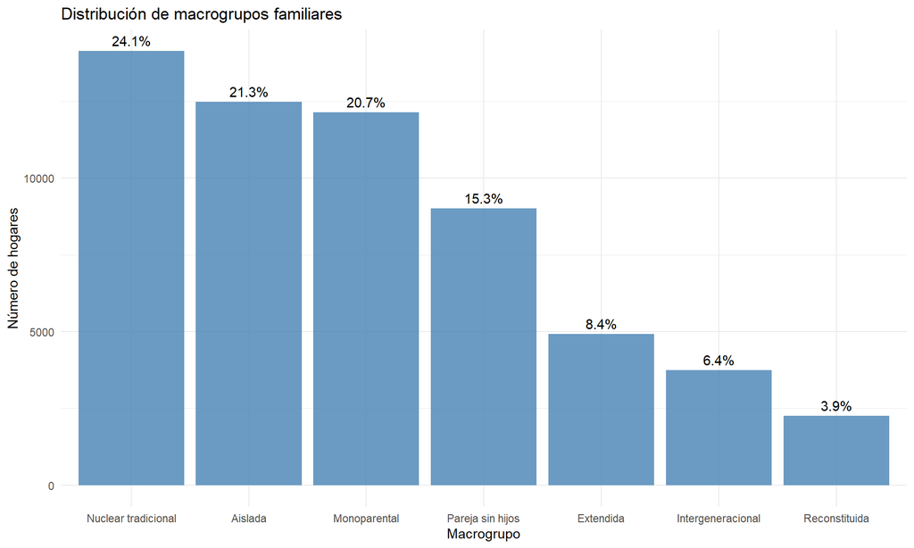

```r
# Distribución de macrogrupos
macro_freq <- data_macro %>%
  distinct(household, .keep_all = TRUE) %>%
  count(macrogrupo) %>%
  mutate(percent = n/sum(n)*100)

ggplot(macro_freq, aes(x = reorder(macrogrupo, -n), y = n)) +
  geom_col(fill = "steelblue", alpha = 0.8) +
  geom_text(aes(label = paste0(round(percent,1), "%")), vjust = -0.5) +
  labs(title = "Distribución de macrogrupos familiares",
       x = "Macrogrupo", y = "Número de hogares") +
  theme_minimal()
```

### 8. Análisis de Macrotipologías (8.Analisis_macrotipologias.R)

Caracterización demográfica de los macrogrupos

Análisis de ingresos por macrogrupo

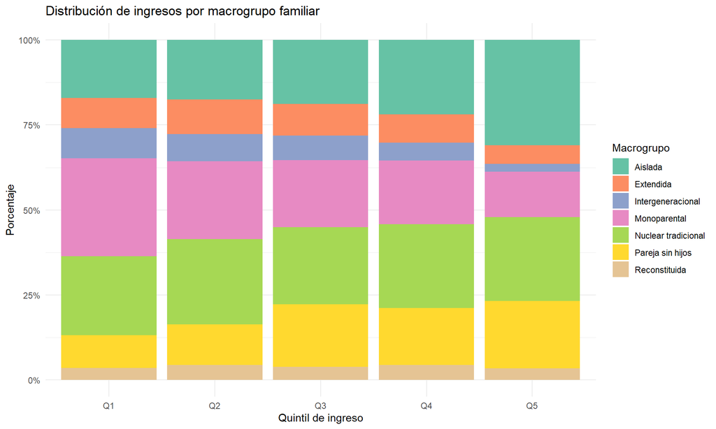

```r
# Gráfico de distribución de ingresos por macrogrupo
ggplot(data_macro, aes(x = sueldo_cat, fill = macrogrupo)) +
  geom_bar(position = "fill") +
  scale_y_continuous(labels = scales::percent) +
  labs(title = "Distribución de ingresos por macrogrupo familiar",
       x = "Quintil de ingreso", y = "Porcentaje") +
  scale_fill_brewer(palette = "Set2", name = "Macrogrupo") +
  theme_minimal()
```

Porcentaje indígena por macrogrupo

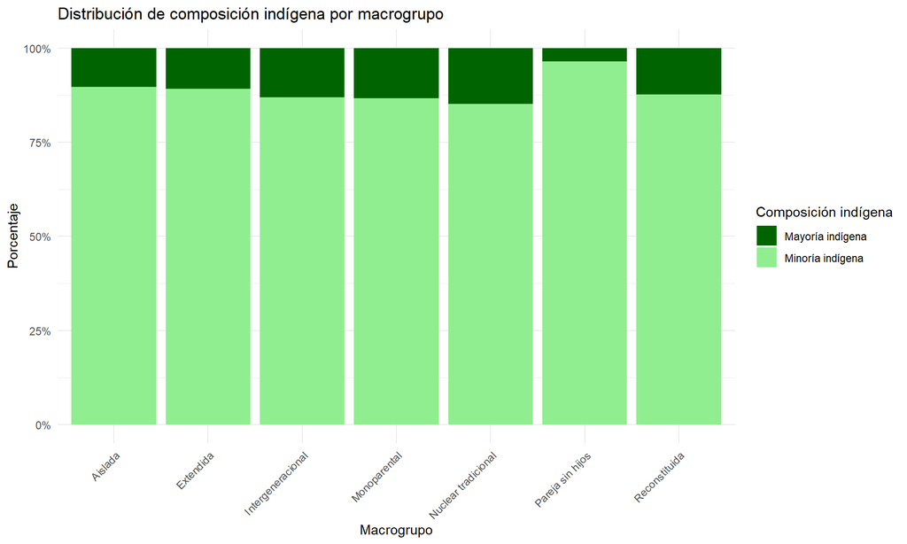

```r
load("Análisis de viviendas/Data/data_macrotiplogias.RData")
ggplot(data_macro, aes(x = macrogrupo, fill = factor(ifelse(porc_ind > 50, "Mayoría indígena", "Minoría indígena")))) +
  geom_bar(position = "fill") +
  scale_y_continuous(labels = scales::percent) +
  labs(title = "Distribución de composición indígena por macrogrupo",
       x = "Macrogrupo", y = "Porcentaje",
       fill = "Composición indígena") +
  scale_fill_manual(values = c("Mayoría indígena" = "darkgreen", "Minoría indígena" = "lightgreen")) +
  theme_minimal() +
  theme(axis.text.x = element_text(angle = 45, hjust = 1))
```

Porcentaje de rural/urbano por macrogrupo

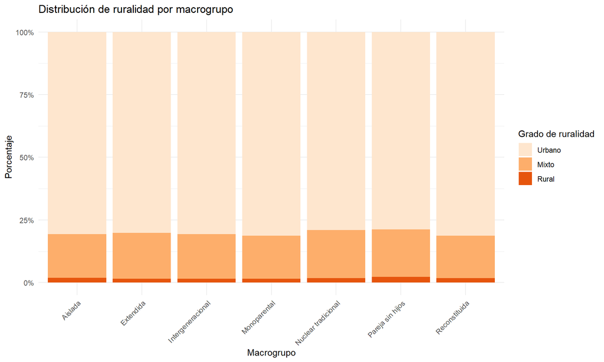

```r
load("Análisis de viviendas/Data/data_macrotiplogias.RData")
# Porcentaje rural por macrogrupo
ggplot(data_macro, aes(x = macrogrupo, fill = rural_cat)) +
  geom_bar(position = "fill") +
  scale_y_continuous(labels = scales::percent) +
  labs(title = "Distribución de ruralidad por macrogrupo",
       x = "Macrogrupo", y = "Porcentaje",
       fill = "Grado de ruralidad") +
  scale_fill_brewer(palette = "Oranges") +
  theme_minimal() +
  theme(axis.text.x = element_text(angle = 45, hjust = 1))
```

### 9. Análisis Estadístico de Macrotipologías (9.Chi2_macrotipologias.R)

Pruebas de chi-cuadrado entre macrogrupos y variables categóricas: - Región - Ruralidad - Nivel de ingresos

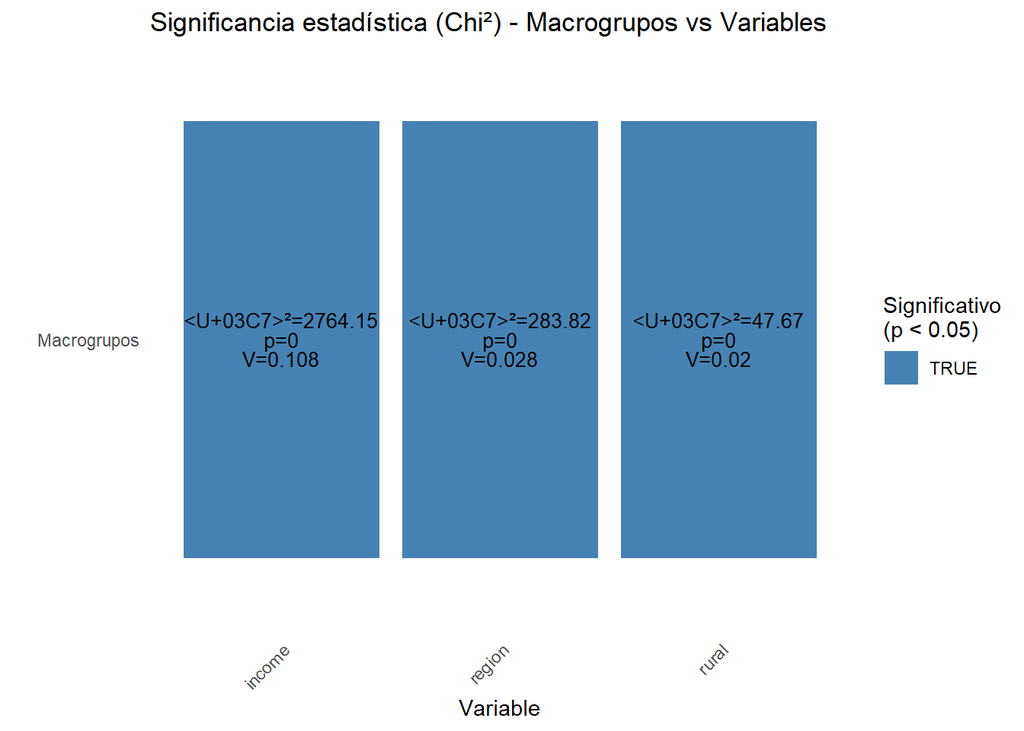

```r
# Pruebas de chi-cuadrado entre macrogrupos y variables categóricas
chi_test_macrogroups <- function(data, test_var) {
  # Crear tabla de contingencia
  tbl <- table(data$macrogrupo, data[[test_var]])

  # Realizar prueba chi-cuadrado
  chi_test <- chisq.test(tbl)

  # Calcular residuos estandarizados
  std_res <- as.data.frame(chi_test$stdres)
  names(std_res) <- c("macrogrupo", test_var, "std_residual")

  # Calcular V de Cramer
  cramer_v <- sqrt(chi_test$statistic / (sum(tbl) * (min(dim(tbl)) - 1)))

  return(list(
    test = chi_test,
    residuals = std_res,
    cramer_v = cramer_v
  ))
}

# Ejecutar pruebas para variables clave
chi_results <- list(
  region = chi_test_macrogroups(data_macro, "region"),
  rural = chi_test_macrogroups(data_macro, "rural_cat"),
  income = chi_test_macrogroups(data_macro, "sueldo_cat")
)

# Heatmap de significancia estadística
chi_summary <- data.frame(
  Variable = c("region", "rural", "income"),
  Chi2 = c(chi_results$region$test$statistic,
           chi_results$rural$test$statistic,
           chi_results$income$test$statistic),
  p_value = c(chi_results$region$test$p.value,
              chi_results$rural$test$p.value,
              chi_results$income$test$p.value),
  Cramer_V = c(chi_results$region$cramer_v,
               chi_results$rural$cramer_v,
               chi_results$income$cramer_v)
)

ggplot(chi_summary, aes(x = Variable, y = "Macrogrupos", fill = p_value < 0.05)) +
  geom_tile(color = "white", width = 0.9, height = 0.9) +
  geom_text(aes(label = paste0("χ²=", round(Chi2, 2),
                               "\np=", round(p_value, 4),
                               "\nV=", round(Cramer_V, 3))),
            color = "black", size = 3.5, lineheight = 0.8) +
  scale_fill_manual(values = c("TRUE" = "steelblue", "FALSE" = "gray90"),
                    name = "Significativo\n(p < 0.05)") +
  labs(title = "Significancia estadística (Chi²) - Macrogrupos vs Variables",
       x = "Variable", y = "") +
  theme_minimal() +
  theme(axis.text.x = element_text(angle = 45, hjust = 1),
        panel.grid = element_blank())
```

Heatmaps de significancia estadística

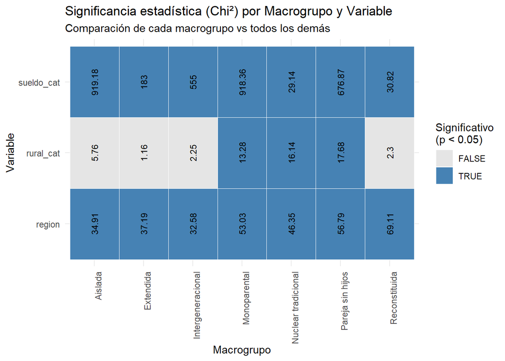

```r
# Crear dataframe con resultados de chi-cuadrado para macrogrupos
chi_macrogrupos <- data.frame(
  Macrogrupo = rep(unique(data_macro$macrogrupo), each = 3),
  Variable = rep(c("region", "rural_cat", "sueldo_cat"), times = length(unique(data_macro$macrogrupo))),
  Chi2 = NA,
  p_value = NA,
  Cramer_V = NA
)

# Calcular pruebas chi-cuadrado para cada combinación macrogrupo-variable
for(i in 1:nrow(chi_macrogrupos)) {
  macrogrupo_sel <- chi_macrogrupos$Macrogrupo[i]
  variable_sel <- chi_macrogrupos$Variable[i]

  # Filtrar datos para el macrogrupo específico vs otros
  datos_filtrados <- data_macro %>%
    mutate(grupo = ifelse(macrogrupo == macrogrupo_sel, macrogrupo_sel, "Otros")) %>%
    filter(!is.na(.data[[variable_sel]]))

  # Crear tabla de contingencia
  tbl <- table(datos_filtrados[[variable_sel]], datos_filtrados$grupo)

  # Realizar prueba chi-cuadrado (suprimir warnings por valores esperados bajos)
  chi_test <- suppressWarnings(chisq.test(tbl))

  # Calcular V de Cramer
  cramer_v <- sqrt(chi_test$statistic / (sum(tbl) * (min(dim(tbl)) - 1)))

  # Almacenar resultados
  chi_macrogrupos$Chi2[i] <- as.numeric(chi_test$statistic)
  chi_macrogrupos$p_value[i] <- chi_test$p.value
  chi_macrogrupos$Cramer_V[i] <- cramer_v
}

# Heatmap de significancia estadística para macrogrupos
ggplot(chi_macrogrupos, aes(x = Macrogrupo, y = Variable, fill = p_value < 0.05)) +
  geom_tile(color = "white") +
  geom_text(aes(label = round(Chi2, 2)), size = 3, angle = 90, color = "black") +
  scale_fill_manual(values = c("TRUE" = "steelblue", "FALSE" = "gray90"),
                    name = "Significativo\n(p < 0.05)") +
  labs(title = "Significancia estadística (Chi²) por Macrogrupo y Variable",
       subtitle = "Comparación de cada macrogrupo vs todos los demás",
       x = "Macrogrupo", y = "Variable") +
  theme_minimal() +
  theme(axis.text.x = element_text(angle = 90, hjust = 1))
```

### 10. Análisis de Correspondencias Múltiples (10.MCA_macrotipologias.R)

Análisis de correspondencias múltiples (MCA) para visualizar relaciones entre: - Macrogrupos familiares - Zonas geográficas (Norte, Centro, Sur) - Grado de ruralidad - Nivel de ingresos - Visualización de la distribución de hogares en el espacio multivariado - Análisis de centroides y elipses de confianza

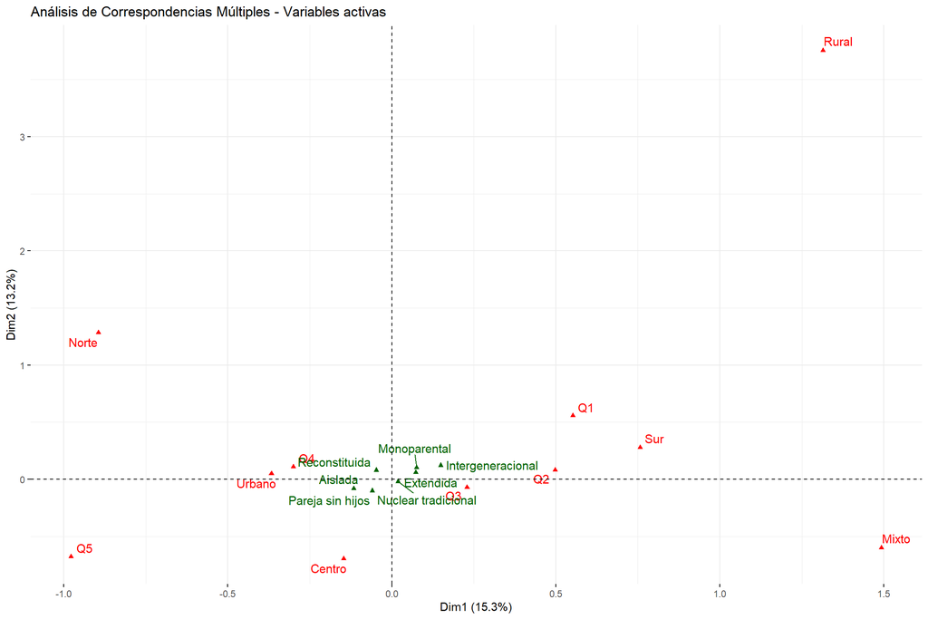

```r
# Preparar datos para MCA
mca_data <- data_macro %>%
  select(macrogrupo, zona, rural_cat, sueldo_cat) %>%
  mutate(across(everything(), as.factor))

# Ejecutar MCA
mca_result <- MCA(mca_data, quali.sup = 1, ncp = 5, graph = FALSE)

# Visualizar variables activas
fviz_mca_var(mca_result, repel = TRUE, ggtheme = theme_minimal(),
             title = "Análisis de Correspondencias Múltiples - Variables activas")
```

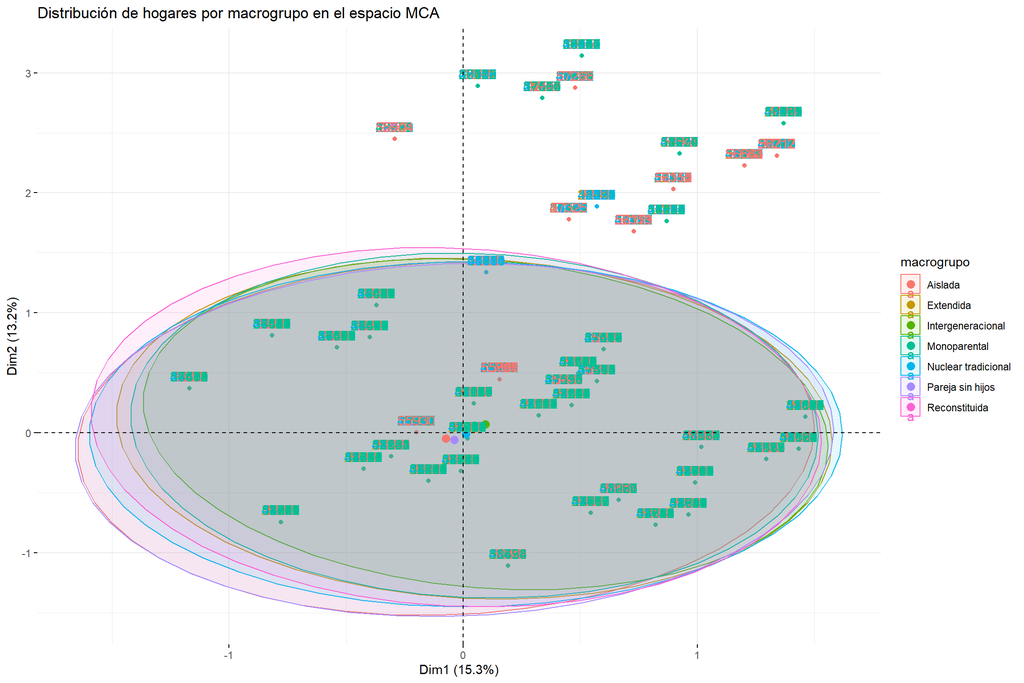

```r
# Visualizar macrogrupos como variable suplementaria
fviz_mca_ind(mca_result, habillage = "macrogrupo", addEllipses = TRUE,
             ggtheme = theme_minimal(),
             title = "Distribución de hogares por macrogrupo en el espacio MCA")
```

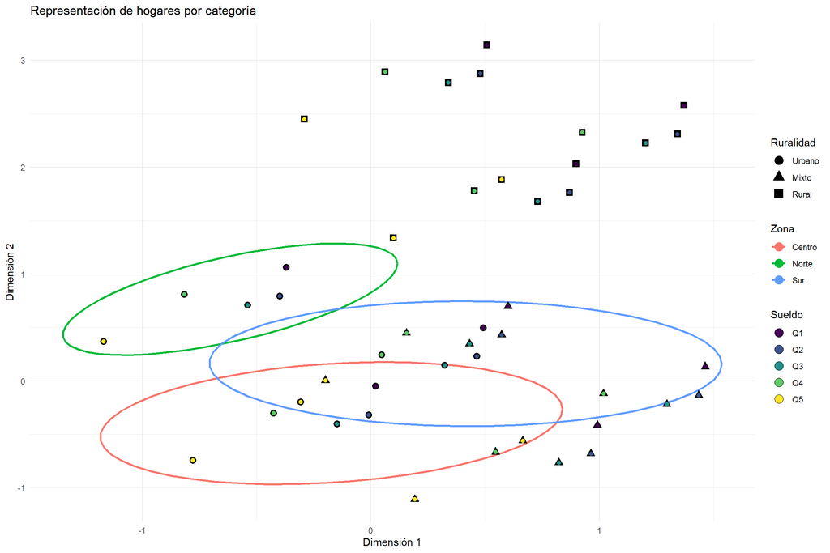

```r
# Gráfico por categorías
coords <- as.data.frame(mca_result$ind$coord)
colnames(coords) <- gsub(" ", "_", colnames(coords))

coords <- coords %>%
  mutate(
    zona = mca_data$zona,
    rural_cat = mca_data$rural_cat,
    sueldo_cat = mca_data$sueldo_cat
  )

# Gráfico con tres leyendas visibles
ggplot(coords, aes(x = Dim_1, y = Dim_2)) +

  # Puntos coloreados por zona
  geom_point(aes(color = zona), alpha = 0.4, size = 2) +

  # Elipses por zona
  stat_ellipse(aes(color = zona), level = 0.95, linewidth = 1) +

  # Diferenciar forma según ruralidad
  geom_point(aes(shape = rural_cat), size = 3, alpha = 0.5) +

  # Contorno según sueldo
  geom_point(aes(fill = sueldo_cat), shape = 21, size = 2, color = "black", alpha = 0.5) +

  # Tema limpio
  theme_minimal() +

  labs(
    title = "Representación de hogares por categoría",
    x = "Dimensión 1",
    y = "Dimensión 2",
    color = "Zona",
    shape = "Ruralidad",
    fill = "Sueldo"
  ) +

  guides(
    color = guide_legend(override.aes = list(size = 4, alpha = 1)),
    shape = guide_legend(override.aes = list(size = 4, alpha = 1)),
    fill = guide_legend(override.aes = list(size = 4, alpha = 1))
  )
```

## Hallazgos Principales

Diversidad Estructural: Se identificaron 48 tipologías estructurales distintas en las redes de parentesco, con las 6 primeras representando más del 50% de los hogares.

Macrogrupos Familiares: Las estructuras familiares se pueden agrupar en 7 macrocategorías con características distintivas:

- Nuclear tradicional (predominante)
- Monoparental
- Reconstituida (con padrastros/madrastras)
- Intergeneracional (tres generaciones)
- Extendida (incluye suegros u otros familiares)
- Aislada (nodos desconectados)
- Pareja sin hijos